```python
import matplotlib.pyplot as plt
import pandas as pd
import seaborn as sns
from IPython.display import Image
from IPython.core.display import HTML
from IPython.display import display
% matplotlib inline
```

```python
HTML('''<script>
code_show=true;
function code_toggle() {
 if (code_show){
 $('div.input').hide();
 } else {
 $('div.input').show();
 }
 code_show = !code_show
}
$( document ).ready(code_toggle);
</script>
<form action="javascript:code_toggle()"><input type="submit" value="Click here to toggle on/off the raw code."></form>''')
```

# WeRateDogs tweets analysis

## Intro

[WeRateDogs](https://twitter.com/dog_rates) is a Twitter account dedicated to rating dogs in a humorous way. Each tweet contains a caption introducing the dog and is accompanied by a photo or a video. The last line of the tweet usually contains the rating of the dog, where the denominator is normally 10, while the numerator is almost always greater than 10. Why? Because "[they're good dogs Brent](https://knowyourmeme.com/memes/theyre-good-dogs-brent)".

It was started in November, 2015 and has grown to more than 7.5 million followers over the past 3 years (as per January, 2019). In this project, we will focus on the tweets for the period betweeen November, 2015 and July, 2017.

We will analyze various trends and patterns, such as:

- Evolution of the account in terms of amout of tweets, retweets and likes per tweet
- Rating distribution and evolution over time
- Ratings, retweets and likes by dog breed
- Most liked and retweeted dogs

```python
tweets = pd.read_csv('tweets_archive.csv', encoding='utf-8')
master = pd.read_csv('twitter_archive_master.csv', encoding='utf-8')
```

```python
tweets.timestamp = pd.to_datetime(tweets.timestamp)
master.timestamp = pd.to_datetime(master.timestamp)
```

## Main Insights

### WeRateDogs evolution over time

WeRateDogs is a great example of a social media account going viral. Let's look into some of the metrics indicating its growth over time.

```python
tweets_per_month = tweets.groupby([tweets.timestamp.dt.year, tweets.timestamp.dt.month])\
.agg({'tweet_id':'count', 'retweet_count': 'mean', 'favorite_count': 'mean'})\
.rename(columns={'tweet_id':'tweets', 'retweet_count': 'retweet_avg', 'favorite_count': 'favorite_avg'})\
.reset_index(drop=True)
tweets_per_month['month'] = pd.date_range('2015-11-01','2017-08-01', freq='MS').strftime("%Y-%m").tolist()
tweets_per_month.set_index('month', inplace=True)
```

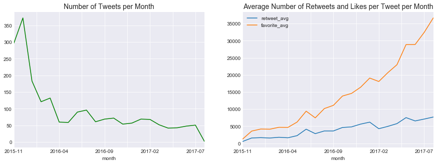

```python
sns.set_style("darkgrid")

fig = plt.figure(figsize=(15,5))

ax1 = fig.add_subplot(121)
ax1.set_title('Number of Tweets per Month', fontsize=14)

tweets_per_month['tweets'].plot(kind='line', ax=ax1, color='green')

ax2 = fig.add_subplot(122)
ax2.set_title('Average Number of Retweets and Likes per Tweet per Month', fontsize=14)

tweets_per_month[['retweet_avg', 'favorite_avg']].plot(kind='line', ax=ax2)

plt.show()
```

There is a clear opposing trend between the amount of tweets published per month and the average amount of likes and retweets. While the amount of tweets per month is steadily decreasing (from around 300 tweets per month in the first 2 months of the account to a more stable number close to 50 tweets per month in 2017), the amount of retweets and favorites are going up, with a steeper upwards trend from the mid 2016.

This overall picture can probably be explained by the mechanics of going viral. In the beginning, a lot of tweets were published per month in order to get traction and capture new followers quickly. As the account grew more popular, the author, Matt Nelson, himself admits that he became more selective as he feels restricted as to what he can say due to the account's immense outreach, and he deletes one out of every ten or fifteen tweets within the first ten minutes if it's not getting enough likes ([see full interview here](https://www.esquire.com/lifestyle/a54940/we-rate-dogs-matt-nelson-interview/)).

### Dog's ratings distribution and evolution

The account's trademark is its unique dogs rating system. Instead of giving them a classical X out of 10 rating where X can be any number up to 10, most of the rating's numerators are actually more than 10, resulting in ratings like 11/10, 12/10, 13/10 etc.

For the purpose of the analysis, the ratings were converted to one decimal number (so, for example a rating of 13/10 would be converted into 1.3). Let's look more in detail at the ratings distribution.

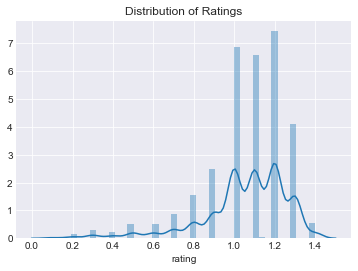

```python
plt.title('Distribution of Ratings')
sns.distplot(master['rating'])
plt.show()
```

The distribution of ratings is left skewed, with most of the ratings concentrated between 1 and 1.3.

Long tail with the lowest rankings reveals that there are actually a lot of rankings that are not assigned to dogs but rather to other animals.

```python
# defining function to show specific tweet's image
def show_image(table, tweetid):
    print(table[table.tweet_id == tweetid]['text'].values[0])
    display(Image(url=table[table.tweet_id == tweetid]['jpg_url'].values[0], width=250, height=250))
```

```python
tweetid = master[(master.rating < 0.5)].sample(5, random_state=1)['tweet_id'].values[4]
show_image(master, tweetid)
```

```
This is Wesley. He's clearly trespassing. Seems rather h*ckin violent too. Weaponized forehead. 3/10 wouldn't let in https://t.co/pL7wbMRW7M
```

[figure not shown]

This leads us to a hypothesis that dogs tend to get higher ratings than non-dogs.

```python
print('Average rating for dogs: ', master[master.is_dog == True]['rating'].mean())
print('Average rating for non-dogs: ', master[master.is_dog == False]['rating'].mean())
```

```
Average rating for dogs:  1.08223206997
Average rating for non-dogs:  0.902302631579
```

As for the evolution of ratings over time, it looks like the average rating per dog is continuously increasing (both for dog predictions and for non-dog predictions).

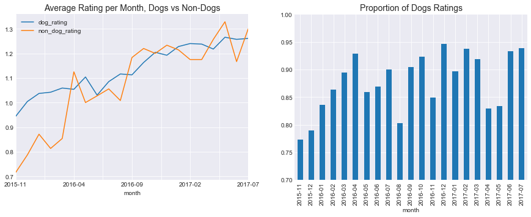

```python
# building table for dog predictions share by month
predictions_by_type = master.groupby([master.timestamp.dt.year, master.timestamp.dt.month])\
.agg({'tweet_id':'count', 'is_dog': 'sum', 'rating': 'mean'})\
.rename(columns={'tweet_id':'predictions'})\
.reset_index(drop=True)

# adding average rating for dog predictions
predictions_by_type['dog_rating'] = master[master.is_dog == True]\
.groupby([master.timestamp.dt.year, master.timestamp.dt.month])['rating'].mean().reset_index(drop=True)

# adding average rating for non-dog predictions
predictions_by_type['non_dog_rating'] = master[master.is_dog == False]\
.groupby([master.timestamp.dt.year, master.timestamp.dt.month])['rating'].mean().reset_index(drop=True)

# adding month as index
predictions_by_type['month'] = pd.date_range('2015-11-01','2017-08-01', freq='MS').strftime("%Y-%m").tolist()
predictions_by_type.set_index('month', inplace=True)

# adding dog ratio per month
predictions_by_type['dog_ratio'] = predictions_by_type.is_dog / predictions_by_type.predictions

fig = plt.figure(figsize=(15,5))

ax1 = fig.add_subplot(121)
ax1.set_title('Average Rating per Month, Dogs vs Non-Dogs', fontsize=14)
predictions_by_type[['dog_rating', 'non_dog_rating']][:-1].plot(kind='line', ax=ax1)

ax2 = fig.add_subplot(122)
ax2.set_ylim((0.7,1))
ax2.set_title('Proportion of Dogs Ratings', fontsize=14)
predictions_by_type['dog_ratio'][:-1].plot(kind='bar', ax=ax2)

plt.show()
```

There is a positive trend in the share of dog ratings vs non-dog ratings in the first 6 months. This can probably explain the growing average rating over this period, since dogs tend to get higher ratings than non-dogs. As for the rest of the upward trend, another possible explanation is that there are more and more good doggos in the world, that is why the average ranking is increasing.

It is also interesting to see that the average ranking during the first two months both for dogs and non-dogs was less than 1 (meaning that some of the rankings at that time actually respected the logic of a X out of 10 ranking). Probably it was after the third month that the author of the tweets decided to stick to the unique rating system that resulted into rankings of more than 1.

### Ratings, retweets and likes by breed

```python
# creating a summary table with info by dog breed
dogs_by_breed = master[master.is_dog == True].groupby('best_prediction')\
.agg({'tweet_id':'count', 'rating': 'mean', 'retweet_count': 'mean', 'favorite_count': 'mean'})\
.rename(columns={'tweet_id':'total'})
```

**Most Common Breeds**

```python
# top 5 most common breeds
dogs_by_breed.sort_values(by='total', ascending=False).head(5)
```

| best_prediction | total | rating | retweet_count | favorite_count |
| --- | --- | --- | --- | --- |
| golden_retriever | 162 | 1.156790 | 3815.851852 | 12569.148148 |
| Labrador_retriever | 112 | 1.116071 | 3758.276786 | 11782.017857 |
| Pembroke | 95 | 1.144211 | 3078.294737 | 10949.284211 |
| Chihuahua | 94 | 1.046809 | 2688.042553 | 7971.361702 |
| pug | 63 | 1.026984 | 1939.476190 | 6300.349206 |

The most common breed of dogs in WeRateDogs archive are retriveres (both Golden Retriever and Labrador). Next comes the Pembroke Corgi, followed by Chihuahua and pug.

**Most Highly Rated Breeds**

```python
# top 5 most highly rated breeds (with at least 10 ratings)
dogs_by_breed[dogs_by_breed.total > 10].sort_values(by='rating', ascending=False).head(5)
```

| best_prediction | total | rating | retweet_count | favorite_count |
| --- | --- | --- | --- | --- |
| Samoyed | 43 | 1.172093 | 4846.046512 | 14068.534884 |
| golden_retriever | 162 | 1.156790 | 3815.851852 | 12569.148148 |
| Great_Pyrenees | 16 | 1.150000 | 4342.562500 | 12027.437500 |
| Pembroke | 95 | 1.144211 | 3078.294737 | 10949.284211 |
| Eskimo_dog | 22 | 1.140909 | 4235.590909 | 10686.545455 |

The highest rating goes to Samoyed, probably due to its fluffiness. Both Golden Retriever and Pembroke Corgi made it to the top rated dogs as well, apart from being one of the most common breeds.

**Most Liked Breeds**

```python
# top 5 most highly liked breeds (with at least 10 ratings)
dogs_by_breed[dogs_by_breed.total > 10].sort_values(by='favorite_count', ascending=False).head(5)
```

| best_prediction | total | rating | retweet_count | favorite_count |
| --- | --- | --- | --- | --- |
| French_bulldog | 31 | 1.119355 | 5039.677419 | 18416.806452 |
| Samoyed | 43 | 1.172093 | 4846.046512 | 14068.534884 |
| cocker_spaniel | 32 | 1.137500 | 4673.593750 | 13142.500000 |
| whippet | 11 | 1.018182 | 4840.272727 | 12911.454545 |
| Cardigan | 21 | 1.114286 | 3798.333333 | 12840.190476 |

Although not having the highest rating, top liked dog breed is French Bulldog. Samoyed seems to be the only breed that is both highly rated and very liked by the audience.

```python
samoyed = master[master.best_prediction == 'Samoyed'].sample(random_state=20)['tweet_id'].values[0]

show_image(master, samoyed)
```

```
Here is Atlas. He went all out this year. 13/10 downright magical af https://t.co/DVYIZOnO81
```

[figure not shown]

## Outro

To conclude our analysis, let's look at the most popular tweets and dogs.

The prize to the most retweeted dog goes to a video of a swimming labrador, realizing for the first time that you can stand in a pool.

```python
most_rt = master.sort_values(by='retweet_count', ascending=False)['tweet_id'].head(1).values[0]

print(master[master.tweet_id == most_rt]['text'].values[0])
display(Image(url=master[master.tweet_id == most_rt]['jpg_url'].values[0], width=250, height=250))
print('Retweets:', master[master.tweet_id == most_rt]['retweet_count'].values[0])
```

```
Here's a doggo realizing you can stand in a pool. 13/10 enlightened af (vid by Tina Conrad) https://t.co/7wE9LTEXC4
```

[figure not shown]

```
Retweets: 79515
```

The most liked tweet is that of a dog participating in the Women's March.

```python
most_liked = master.sort_values(by='favorite_count', ascending=False)['tweet_id'].head(1).values[0]

print(master[master.tweet_id == most_liked]['text'].values[0])
display(Image(url=master[master.tweet_id == most_liked]['jpg_url'].values[0], width=250, height=250))
print('Likes:', master[master.tweet_id == most_liked]['favorite_count'].values[0])
```

```
Here's a super supportive puppo participating in the Toronto  #WomensMarch today. 13/10 https://t.co/nTz3FtorBc
```

[figure not shown]

```
Likes: 132810
```

And remember: regardless of the rating, the amount of likes or retweets, they are all good doggos!